# English Pemier League

aaron chola

2024-02-28

# `English Premier League Analysis`

#### In this project will answer the following questions

1.Does the home stadium give an advantage and if yes how?

[figure not shown]

2.What is the best way of winning matches, is it defensive or attacking.

3.Who is the best coach in premier league history.

[figure not shown]

[figure not shown]

### Loading data

```r
Data<-read.csv("C:\\Users\\CHOLA\\Desktop\\my_data.csv")
head(Data)
```

```
##   Competition_Name Gender Country Season_End_Year Round Wk Day       Date Time
## 1   Premier League      M     ENG            1993    NA  1 Sat 1992-08-15 <NA>
## 2   Premier League      M     ENG            1993    NA  1 Sat 1992-08-15 <NA>
## 3   Premier League      M     ENG            1993    NA  1 Sat 1992-08-15 <NA>
## 4   Premier League      M     ENG            1993    NA  1 Sat 1992-08-15 <NA>
## 5   Premier League      M     ENG            1993    NA  1 Sat 1992-08-15 <NA>
## 6   Premier League      M     ENG            1993    NA  1 Sat 1992-08-15 <NA>
##             Home HomeGoals            Away AwayGoals Attendance           Venue
## 1    Southampton         0       Tottenham         0      19654        The Dell
## 2  Coventry City         2   Middlesbrough         1      12681  Highfield Road
## 3  Sheffield Utd         2  Manchester Utd         1      28070    Bramall Lane
## 4        Arsenal         2    Norwich City         4      24030        Highbury
## 5 Crystal Palace         3       Blackburn         3      17086   Selhurst Park
## 6        Chelsea         1 Oldham Athletic         1      20699 Stamford Bridge
##         Referee Notes
```

[output cut: 20 more lines]

```r
names(Data)
```

```
##  [1] "Competition_Name" "Gender"           "Country"          "Season_End_Year"
##  [5] "Round"            "Wk"               "Day"              "Date"
##  [9] "Time"             "Home"             "HomeGoals"        "Away"
## [13] "AwayGoals"        "Attendance"       "Venue"            "Referee"
## [17] "Notes"            "MatchURL"         "Home_xG"          "Away_xG"
```

### Loading the library for data analysis

```r
library(tidyverse)
```

#### Data manipulation and data cleaning using dplr

```r
PL<-Data %>%
  arrange(Season_End_Year,Wk)%>%
  select(Season_End_Year,Wk,Date,Home,HomeGoals,AwayGoals,Away,Date) %>% mutate(Date=ymd(Date))
```

This shows that for 2023-2024 Company we are remaining with 131 games

```r
colSums(is.na(PL))
```

```
## Season_End_Year              Wk            Date            Home       HomeGoals
##               0               0               0               0             131
##       AwayGoals            Away
##             131               0
```

```r
str(PL)
```

```
## 'data.frame':    12406 obs. of  7 variables:
##  $ Season_End_Year: int  1993 1993 1993 1993 1993 1993 1993 1993 1993 1993 ...
##  $ Wk             : int  1 1 1 1 1 1 1 1 1 1 ...
##  $ Date           : Date, format: "1992-08-15" "1992-08-15" ...
##  $ Home           : chr  "Southampton" "Coventry City" "Sheffield Utd" "Arsenal" ...
##  $ HomeGoals      : int  0 2 2 2 3 1 2 1 1 1 ...
##  $ AwayGoals      : int  0 1 1 4 3 1 1 1 1 0 ...
##  $ Away           : chr  "Tottenham" "Middlesbrough" "Manchester Utd" "Norwich City" ...
```

We now add the final description of home,away and draw(H=Home Win, D=Draw, A=Away Win)

```r
PL$FTR<- case_when(
                  PL$HomeGoals>PL$AwayGoals~"HOME_WINS",
                  PL$HomeGoals<PL$AwayGoals~"AWAY_WINS",
                  PL$HomeGoals==PL$AwayGoals~"DRAWS"
                     )
```

# Data processsing

Descriptive by summary

```r
summary(PL)
```

```
##  Season_End_Year       Wk             Date                Home
##  Min.   :1993    Min.   : 1.00   Min.   :1992-08-15   Length:12406
##  1st Qu.:2000    1st Qu.:10.00   1st Qu.:2000-01-03   Class :character
##  Median :2008    Median :20.00   Median :2008-02-10   Mode  :character
##  Mean   :2008    Mean   :19.72   Mean   :2008-03-19
##  3rd Qu.:2016    3rd Qu.:29.00   3rd Qu.:2016-04-09
##  Max.   :2024    Max.   :42.00   Max.   :2024-05-19
##
##    HomeGoals       AwayGoals         Away               FTR
##  Min.   :0.000   Min.   :0.000   Length:12406       Length:12406
##  1st Qu.:1.000   1st Qu.:0.000   Class :character   Class :character
##  Median :1.000   Median :1.000   Mode  :character   Mode  :character
##  Mean   :1.529   Mean   :1.149
##  3rd Qu.:2.000   3rd Qu.:2.000
##  Max.   :9.000   Max.   :9.000
##  NA's   :131     NA's   :131
```

We see that week has a maximum of 42 which means games are played within 42 weeks

```r
table(PL$Season_End_Year)
```

```
##
## 1993 1994 1995 1996 1997 1998 1999 2000 2001 2002 2003 2004 2005 2006 2007 2008
##  462  462  462  380  380  380  380  380  380  380  380  380  380  380  380  380
## 2009 2010 2011 2012 2013 2014 2015 2016 2017 2018 2019 2020 2021 2022 2023 2024
##  380  380  380  380  380  380  380  380  380  380  380  380  380  380  380  380
```

We see that from 1993 to 1995 the number of games that were played were 462 this is because by then the number of teams were 22 and were reduced to 20 in 1996.

- **We will now answer the first question ,which is if the home stadium gives an advantage and find out with what chances.**

```r
#We are going to generate a new dataframe that includes the percentage of different game results, where 'H' denotes a home team win, 'A' denotes an away team win, and 'D' denotes a draw.
Home_vs_Away<-count(PL,FTR) %>% arrange(desc(n))

Home_vs_Away$percentage<-(Home_vs_Away$n/sum((Home_vs_Away$n)))*100
```

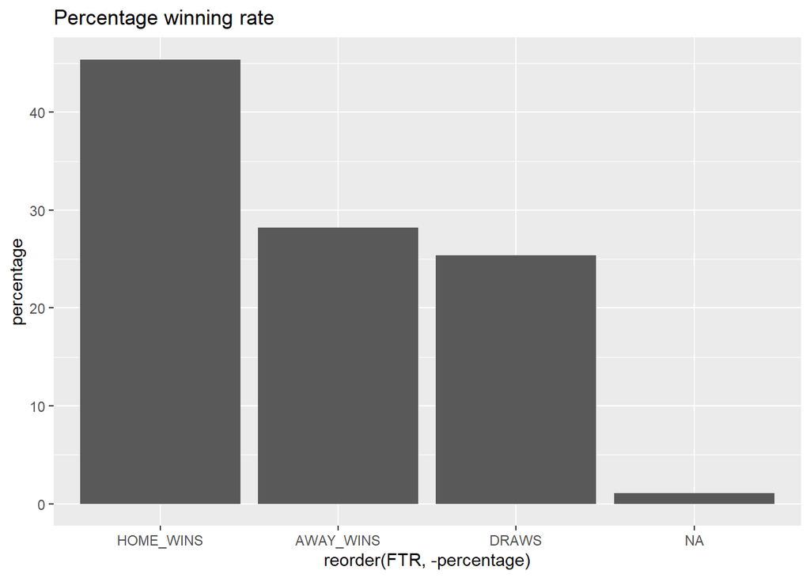

```r
  ggplot(data = Home_vs_Away,aes(x=reorder(FTR,-percentage),y=percentage))+
    geom_col()+labs(title = "Percentage winning rate")
```

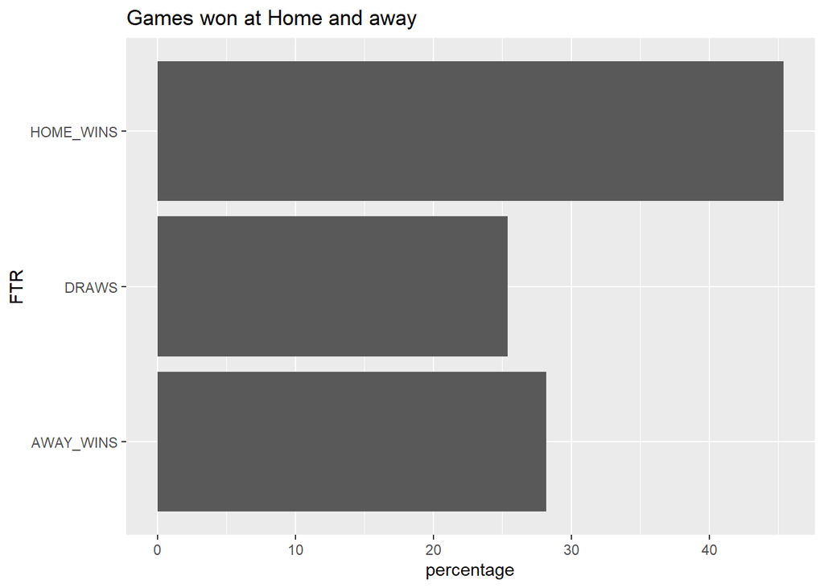

```r
home_vs_away<-na.omit(Home_vs_Away)

ggplot(data=home_vs_away,mapping = aes(x=FTR,y=percentage))+geom_col()+coord_flip()+labs(title = "Games won at Home and away")
```

By comparing the win percentages for home and away games, you can quantify the advantage of playing at the home ground. Typically, you would expect the win percentage for home games to be higher than for away games, indicating a home ground advantage.

The **NA** shows the number of games not played as this data goes up to 2024 company and we still have remaining games.

As We see that the number of games won at Home were greater than the draws and away games.

Now we will find out with what chances or probability do teams have of wining at home and away.

```r
home_vs_away$probability<-(home_vs_away$n/sum((home_vs_away$n)))
home_vs_away
```

```
##         FTR    n percentage probability
## 1 HOME_WINS 5631   45.38933   0.4587373
## 2 AWAY_WINS 3496   28.17991   0.2848065
## 3     DRAWS 3148   25.37482   0.2564562
```

- $P(A)$ is the probability of an outcome
- $n(S)$ is the number of favorable outcomes for event $A$.
- $n(S)$ is the total number of possible outcomes in the sample space.

We see that the probability of wining at home is $0.4587373$ and hence we can conclude that teams have great chances of winning at home than away.

```r
## new dataframe counting final results by every year
point_year<-PL%>%
  group_by(Season_End_Year)%>%
  count(FTR)
point_year
```

```
## # A tibble: 97 × 3
## # Groups:   Season_End_Year [32]
##    Season_End_Year FTR           n
##              <int> <chr>     <int>
##  1            1993 AWAY_WINS   118
##  2            1993 DRAWS       130
##  3            1993 HOME_WINS   214
##  4            1994 AWAY_WINS   128
##  5            1994 DRAWS       142
##  6            1994 HOME_WINS   192
##  7            1995 AWAY_WINS   123
##  8            1995 DRAWS       134
##  9            1995 HOME_WINS   205
## 10            1996 AWAY_WINS    96
## # ℹ 87 more rows
```

We will now calculate the number of points by away game and home games

```r
## calculating the points that collected in a home and away ground
point_year$points<-case_when(point_year$FTR=="HOME_WINS"~point_year$n*3,
                             point_year$FTR=="AWAY_WINS"~point_year$n*3,
                             point_year$FTR=="DRAWS"~point_year$n*1
                             )
point_year
```

```
## # A tibble: 97 × 4
## # Groups:   Season_End_Year [32]
##    Season_End_Year FTR           n points
##              <int> <chr>     <int>  <dbl>
##  1            1993 AWAY_WINS   118    354
##  2            1993 DRAWS       130    130
##  3            1993 HOME_WINS   214    642
##  4            1994 AWAY_WINS   128    384
##  5            1994 DRAWS       142    142
##  6            1994 HOME_WINS   192    576
##  7            1995 AWAY_WINS   123    369
##  8            1995 DRAWS       134    134
##  9            1995 HOME_WINS   205    615
## 10            1996 AWAY_WINS    96    288
## # ℹ 87 more rows
```

We will now find the number of points accumulated at home and away in each year

```r
## creating a new column"h_points" that summation points that collected in home ground either "h_points" to away points
point_year2<-na.omit(point_year)%>%
  group_by(Season_End_Year)%>%
  summarize(home_points=points[FTR=="HOME_WINS"]+points[FTR=="DRAWS"],away_points=(points[FTR=="AWAY_WINS"])+points[FTR=="DRAWS"])
point_year2
```

```
## # A tibble: 32 × 3
##    Season_End_Year home_points away_points
##              <int>       <dbl>       <dbl>
##  1            1993         772         484
##  2            1994         718         526
##  3            1995         749         503
##  4            1996         656         386
##  5            1997         605         416
##  6            1998         647         398
##  7            1999         622         403
##  8            2000         653         395
##  9            2001         653         386
## 10            2002         596         443
## # ℹ 22 more rows
```

We will now make the table in to a tidy table

```r
## tidying the data
point_year3<-point_year2%>%
  pivot_longer(c(`home_points`, `away_points`), names_to = "Home_vs_Away", values_to = "Points")
point_year3
```

```
## # A tibble: 64 × 3
##    Season_End_Year Home_vs_Away Points
##              <int> <chr>         <dbl>
##  1            1993 home_points     772
##  2            1993 away_points     484
##  3            1994 home_points     718
##  4            1994 away_points     526
##  5            1995 home_points     749
##  6            1995 away_points     503
##  7            1996 home_points     656
##  8            1996 away_points     386
##  9            1997 home_points     605
## 10            1997 away_points     416
## # ℹ 54 more rows
```

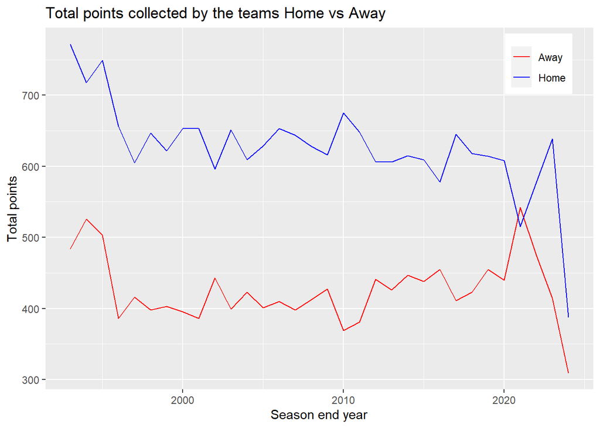

```r
ggplot(data = point_year3,aes(x=Season_End_Year,y=Points,col=Home_vs_Away))+
  geom_line()+
  theme(legend.title=element_blank())+
  theme(legend.position=c(0.9,0.9))+
  scale_color_manual(labels = c("Away", "Home"),
                     values = c( "red", "blue"))+
  ggtitle("Total points collected by the teams Home vs Away")+
  xlab("Season end year")+
  ylab("Total points")
```

**The home winning percetage through the years**

```r
## new dataframe counting the Home, Away and Draw through the years
home_vs_away_years<-PL %>%
  group_by(Season_End_Year,FTR)%>%
  count(FTR)

##the percentage of every case
home_vs_away_years$Season_End_Year<-as.numeric(home_vs_away_years$Season_End_Year)

home_vs_away_years$percentage<- case_when(
  home_vs_away_years$Season_End_Year==1993~home_vs_away_years$n*100/462,
  home_vs_away_years$Season_End_Year==1994~home_vs_away_years$n*100/462,
  home_vs_away_years$Season_End_Year==1995~home_vs_away_years$n*100/462,
  TRUE ~ home_vs_away_years$n*100/380
                                         )

home_vs_away_year<-na.omit(home_vs_away_years)

home_vs_away_year
```

```
## # A tibble: 96 × 4
## # Groups:   Season_End_Year, FTR [96]
##    Season_End_Year FTR           n percentage
##              <dbl> <chr>     <int>      <dbl>
##  1            1993 AWAY_WINS   118       25.5
##  2            1993 DRAWS       130       28.1
##  3            1993 HOME_WINS   214       46.3
##  4            1994 AWAY_WINS   128       27.7
##  5            1994 DRAWS       142       30.7
##  6            1994 HOME_WINS   192       41.6
##  7            1995 AWAY_WINS   123       26.6
##  8            1995 DRAWS       134       29.0
##  9            1995 HOME_WINS   205       44.4
## 10            1996 AWAY_WINS    96       25.3
## # ℹ 86 more rows
```

We will now find the year with the **highest away win**

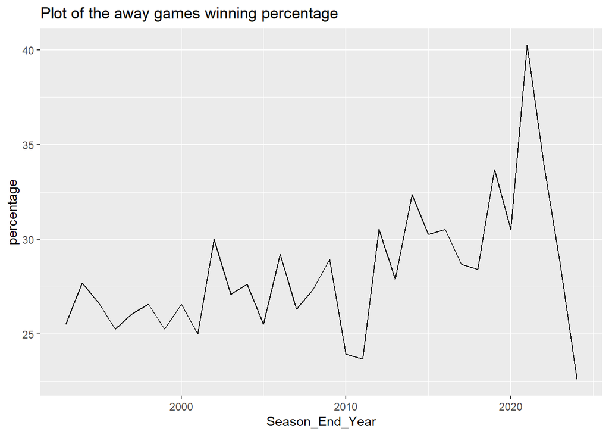

```r
away_games_year<-home_vs_away_year %>% filter(FTR=="AWAY_WINS")

ggplot(data = away_games_year,mapping = aes(x=Season_End_Year,y=percentage))+geom_line()+labs(title = "Plot of the away games winning percentage"  )
```

plotting the Home winning percentage through the years

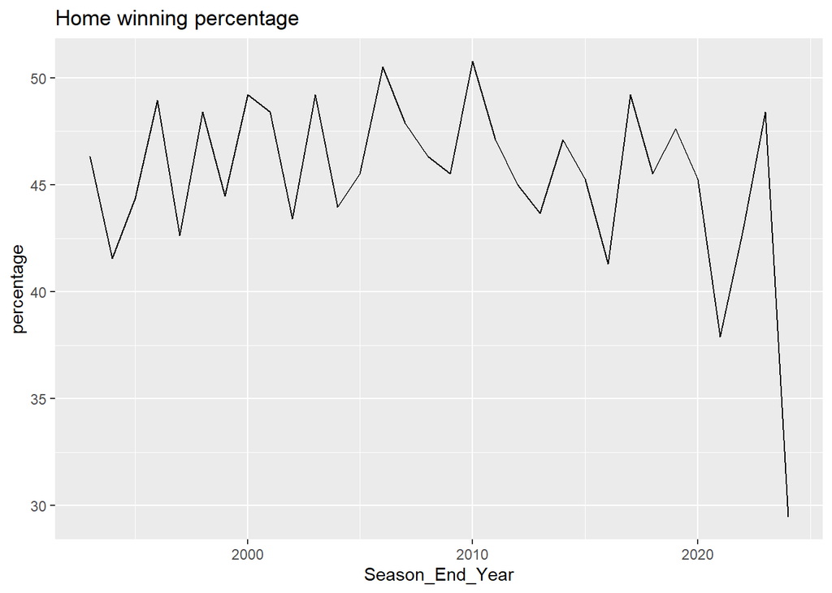

```r
Home_wins<-home_vs_away_year %>% filter(FTR=="HOME_WINS")
ggplot(data = Home_wins,mapping = aes(x=Season_End_Year,y=percentage))+geom_line()+labs(title = "Home winning percentage")
```

**Observation**

The home team’s success rate remained consistently above 40% over the years until experiencing a notable decline in 2021, before eventually rebounding to its usual levels. We will revisit this particular scenario later in our analysis to determine its potential influence on scoring goals at the home stadium.

Now we will try to find the effect home field have on the number of goals scored?

```r
home_goals_vs_away_goals<-PL %>%
  group_by(Season_End_Year)%>%
  summarise(all_home_goals=sum(HomeGoals),all_away_goals=sum(AwayGoals))
```

we can now make the table tidy

```r
home_goals_vs_away_goals2<-home_goals_vs_away_goals %>% pivot_longer(cols = c('all_home_goals','all_away_goals'),names_to = 'Home_and_away_goals',values_to = 'total_goals')
home_vs_away_goals3<-na.omit(home_goals_vs_away_goals2)
```

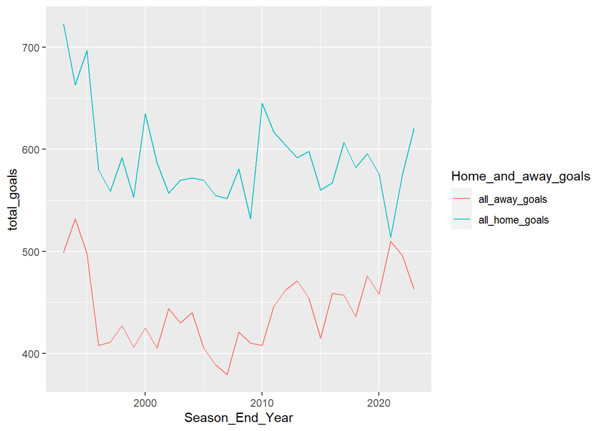

```r
ggplot(data = home_vs_away_goals3,mapping = aes(x=Season_End_Year,y=total_goals,col=Home_and_away_goals,))+geom_line()
```

The home advantage, evident in both points accumulation and goal-scoring throughout the years, was disrupted notably in $2021$. Upon closer examination of this period, it became apparent that $2021$ coincided with the onset of the COVID-19 pandemic, resulting in matches being played without spectators. Delving deeper into this timeframe, data from “premierleague.com” reveals that the last 92 matches of the $2019-2020$ season were played behind closed doors, and the entirety of the $2020–21$ season followed suit, with only brief exceptions in December $2020$ and May $2021$ when limited numbers of fans were permitted. This prompts us to investigate the impact of crowd absence throughout the $2020–2021$ season on various aspects of the game.

```r
## new dataframe with only results of 2020-2021 season
season_2021<-subset(PL,Season_End_Year=="2021")
```

Home vs Away winning in 2021 season

```r
point_2021<-season_2021%>%
  group_by(Season_End_Year)%>%
  count(FTR)
point_2021
```

```
## # A tibble: 3 × 3
## # Groups:   Season_End_Year [1]
##   Season_End_Year FTR           n
##             <int> <chr>     <int>
## 1            2021 AWAY_WINS   153
## 2            2021 DRAWS        83
## 3            2021 HOME_WINS   144
```

plotting the result

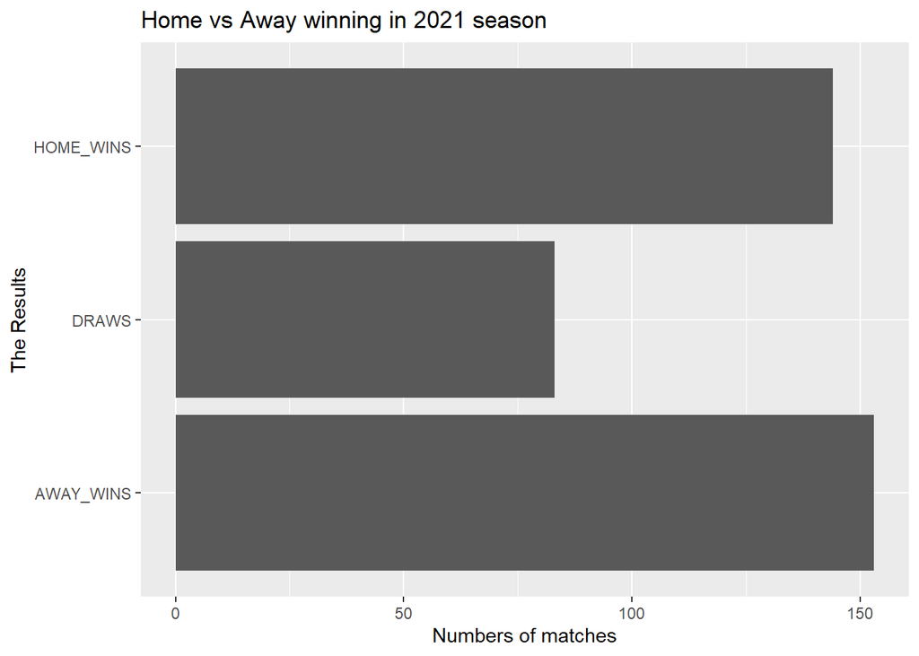

```r
ggplot(data =point_2021,mapping=aes(x=FTR,y=n))+
  geom_col()+coord_flip()+
  ggtitle("Home vs Away winning in 2021 season")+
  ylab("Numbers of matches")+
  xlab("The Results")
```

The absence of a crowd has evidently nullified the home advantage in sports. Now, shifting our focus to team analysis, we’ll begin by identifying the team with the highest number of victories at their home stadium.

This exploration will provide insights into teams’ strengths and performances in their familiar home environments.

```r
## new dataframe to calculate the home results for each PL team
home_point<-PL %>%
  group_by(Home)%>%
  count(FTR)
Home_points<-na.omit(home_point)

## replacing "H" by "W" for winning, "A" by "L" for losing and "D" still "D" for draw
Home_points$FTR[Home_points$FTR=="HOME_WINS"]<-"W"
Home_points$FTR[Home_points$FTR=="AWAY_WINS"]<-"L"
Home_points$FTR[Home_points$FTR=="DRAWS"]<-"D"

## calculating the points collected at home ground by each team
## as we know the winning team get three points, the losing team take nothing, and 1 point for each team during draw
Home_points$points<- case_when(Home_points$FTR=="L"~Home_points$n*0,
                               Home_points$FTR=="W"~Home_points$n*3,
                               Home_points$FTR=="D"~Home_points$n*1
                               )

home_point2<-Home_points%>%
  group_by(Home)%>%
  summarize(T_point=sum(points))
```

plotting the result of points in home ground

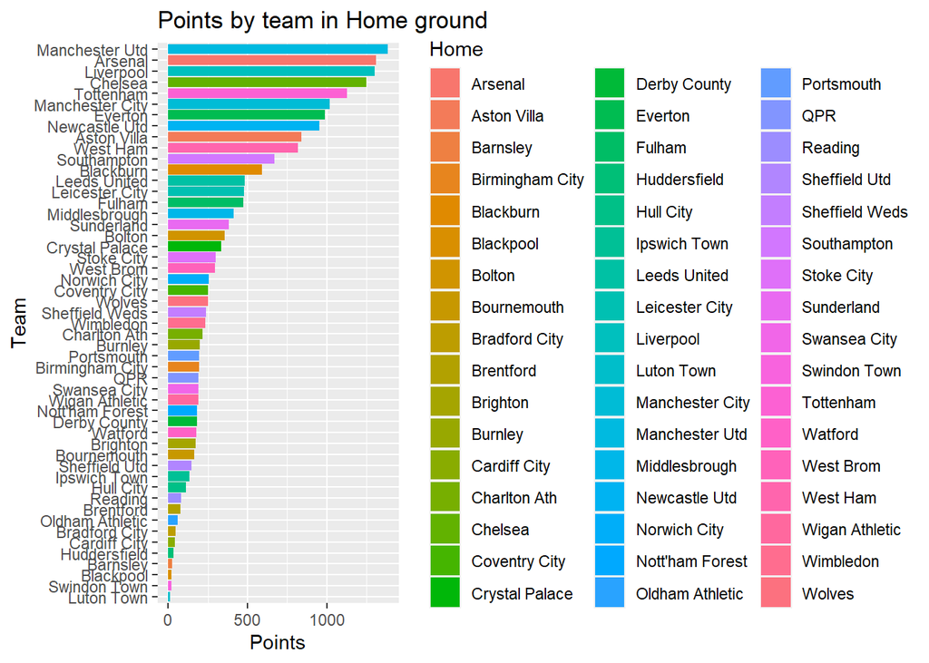

```r
ggplot(data = home_point2,aes(x=T_point,y=reorder(Home,T_point),fill=Home))+
  geom_col()+
  ggtitle("Points by team in Home ground")+
  ylab("Team")+
  xlab("Points")
```

Manchester United stands out as the team with the highest number of points accumulated at their home stadium, followed closely by Arsenal, Liverpool, and Chelsea.

Let’s move to the other side and see the teams’ performances individually in away matches.

```r
## new dataframe to calculate the home results for each PL team
away_point<-PL %>%
  group_by(Away)%>%
  count(FTR)
Away_point<-na.omit(away_point)

## replacing "H" by "L" for losing, "A" by "W" for winning and "D" still "D" for draw
Away_point$FTR[Away_point$FTR=="HOME_WINS"]<-"L"
Away_point$FTR[Away_point$FTR=="AWAY_WINS"]<-"W"
Away_point$FTR[Away_point$FTR=="DRAWS"]<-"D"

## calculating the points collected at away ground by each team
## as we know the winning team get three points, the losing team take nothing, and 1 point for each team during draw
Away_point$points<- case_when(Away_point$FTR=="L"~Away_point$n*0,
                              Away_point$FTR=="W"~Away_point$n*3,
                              Away_point$FTR=="D"~Away_point$n*1
                              )

away_point2<-Away_point%>%
  group_by(Away)%>%
  summarize(T_point=sum(points))
```

plotting the result of away point accumulated

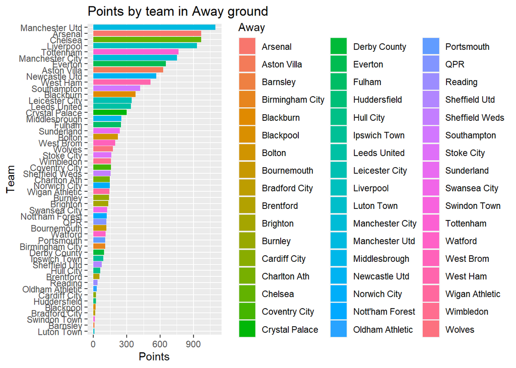

```r
ggplot(data = away_point2,aes(x=T_point,y=reorder(Away,T_point),fill=Away))+
  geom_col()+
  ggtitle("Points by team in Away ground")+
  ylab("Team")+
  xlab("Points")
```

**We will now try to find What is the best way of winning matches, is it defensive or attacking.**

In this section, we’ll evaluate different techniques for collecting points based on their offensive and defensive capabilities, primarily through goals scored and goals received. We’ll analyze the number of goals scored and the average points collected by the team, as well as the number of goals conceded and the average points collected.

```r
## to see how many Home teams scored by end of the match
table(PL$HomeGoals)
```

```
##
##    0    1    2    3    4    5    6    7    8    9
## 2865 3972 2973 1503  635  219   69   28    7    4
```

```r
## to see how many Away teams scored by end of the match
table(PL$AwayGoals)
```

```
##
##    0    1    2    3    4    5    6    7    8    9
## 4165 4250 2354 1044  336   90   30    3    2    1
```

We see that both scores are in the range of 0 to 9

```r
PL_r<-na.omit(PL)
```

```r
## creating a matrix with 4 variables
## variable for goals the team scored in a match "Goal_scored" and next to it the average point they got "points_s",
## and  variable for goals the team received in a match "Goal_received" and next to it the average point they got "points_A".
## and our observations the range from 0 to 9
matrix<-matrix(nrow = 10,ncol = 4)
colnames(matrix)=c("Goal_scored","points_s","Goal_received","points_A")
matrix[,1]<-c(0:9)
matrix[,3]<-c(0:9)

## creating a loop to calculate the average point when scoring a goals in a range from 0 to 9
for(i in 0:9)
{
## in Home ground
  home_score_i<-subset(PL_r,PL_r$HomeGoals==i)

  home_score_i$points_h_i<-case_when(home_score_i$FTR=="HOME_WINS"~3,
                                     home_score_i$FTR=="DRAWS"~1,
                                     home_score_i$FTR=="AWAY_WINS"~0
                                     )
  all_points_gains_at_home_when_scored_i<-sum(home_score_i$points_h_i)

 ## in away grounds
  away_score_i<-subset(PL_r,PL_r$AwayGoals==i)

  away_score_i$points_a_i<-case_when(away_score_i$FTR=="HOME_WINS"~0,
                                     away_score_i$FTR=="DRAWS"~1,
                                     away_score_i$FTR=="AWAY_WINS"~3
                                     )
  all_points_gains_at_away_when_scored_i<-sum(away_score_i$points_a_i)

  all_points_gains_when_scored_i<-all_points_gains_at_away_when_scored_i+all_points_gains_at_home_when_scored_i

  average_points_when_scored_i<-all_points_gains_when_scored_i/(nrow(home_score_i)+nrow(away_score_i))

  matrix[i+1,2]<-(average_points_when_scored_i)
}

## creating a loop to calculate the average point when receiving a goals in a range from 0 to 9
for(j in 0:9)

{
## in Home ground
  home_against_j<-subset(PL_r,PL_r$AwayGoals==j)
  home_against_j$points_h_j<-case_when(home_against_j$FTR=="HOME_WINS"~3,
                                       home_against_j$FTR=="DRAWS"~1,
                                       home_against_j$FTR=="AWAY_WINS"~0
                                       )
  all_points_gains_at_home_when_against_j<-sum(home_against_j$points_h_j)

  ## in Away grounds
  away_against_j<-subset(PL_r,PL_r$HomeGoals==j)
  away_against_j$points_a_j<-case_when(away_against_j$FTR=="HOME_WINS"~0,
                                       away_against_j$FTR=="DRAWS"~1,
                                       away_against_j$FTR=="AWAY_WINS"~3
                                       )
  all_points_gains_at_away_when_against_j<-sum(away_against_j$points_a_j)

  all_points_gains_when_against_j<-all_points_gains_at_away_when_against_j+all_points_gains_at_home_when_against_j

  average_points_when_against_j<-all_points_gains_when_against_j/(nrow(home_against_j)+nrow(away_against_j))

  matrix[j+1,4]<-(average_points_when_against_j)

}
goals_points<-as.data.frame(matrix)
```

```r
head(goals_points,10)
```

```
##    Goal_scored  points_s Goal_received    points_A
## 1            0 0.2805121             0 2.438975818
## 2            1 1.1432741             1 1.513986865
## 3            2 2.1334710             2 0.639384269
## 4            3 2.6556733             3 0.242245779
## 5            4 2.9052523             4 0.059732235
## 6            5 2.9870550             5 0.006472492
## 7            6 3.0000000             6 0.000000000
## 8            7 3.0000000             7 0.000000000
## 9            8 3.0000000             8 0.000000000
## 10           9 3.0000000             9 0.000000000
```

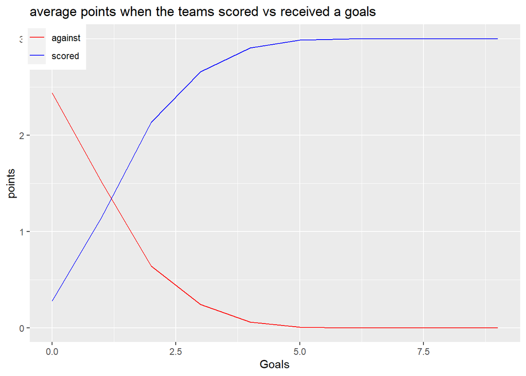

```r
## tidying and plotting the data

goals_points2<-goals_points%>%
  pivot_longer(c(`points_s`, `points_A`), names_to = "scored_vs_against", values_to = "Points")

ggplot(data = goals_points2,aes(x=Goal_scored,y=Points,col=scored_vs_against))+
  geom_line()+
  theme(legend.title=element_blank())+
  theme(legend.position=c(0.05,0.94))+
  scale_color_manual(labels = c("against", "scored"),
  values = c( "red", "blue"))+
  ggtitle("average points when the teams scored vs received a goals")+
  xlab("Goals")+
  ylab("points")
```

The outcome is somewhat unexpected, as it reveals that, on average, a team that keeps a clean sheet gathers 2.43 points, surpassing the average of 2.13 points collected by a team scoring two goals. Additionally, a team conceding only one goal accumulates more points on average than a team scoring just one goal.

```r
## creating a list that will contain every PL table
PL_Table<-list()

## creating a loop to deal with the data year by year
for(i in 1993:2022)
{
## creating subset contain every year results
PL_r_i<-subset(PL_r,PL_r$Season_End_Year==i)

## count of home goals, scored and against

PL_r_hgi<-PL_r_i%>%
  group_by(Home)%>%
  summarize(goal_scored_at_home=sum(HomeGoals),
            goal_against_at_home=sum(AwayGoals))

## count of away goals, scored and against
PL_r_agi<-PL_r_i%>%
  group_by(Away)%>%
  summarize(goal_scored_at_away=sum(AwayGoals),
            goal_against_at_away=sum(HomeGoals))

##home_and_away_goals

goals_i<-cbind(PL_r_hgi,PL_r_agi)
goals_i$GS<-(goals_i$goal_scored_at_away)+(goals_i$goal_scored_at_home)
goals_i$GA<-(goals_i$goal_against_at_away)+(goals_i$goal_against_at_home)
goals_i$GD<-(goals_i$GS)-(goals_i$GA)

goals2_i<-goals_i%>%
  select(Home,GS,GA,GD)

##home result
PL_r_hri<-PL_r_i%>%
  group_by(Home)%>%
  count(FTR)

PL_r_hri$W<-case_when(PL_r_hri$FTR=="HOME_WINS"~PL_r_hri$n*1,
                      PL_r_hri$FTR=="DRAWS"~0,
                      PL_r_hri$FTR=="AWAY_WINS"~0
                       )

PL_r_hri$D<-case_when(PL_r_hri$FTR=="HOME_WINS"~0,
                      PL_r_hri$FTR=="DRAWS"~PL_r_hri$n*1,
                      PL_r_hri$FTR=="AWAY_WINS"~0
                   )

PL_r_hri$L<-case_when(PL_r_hri$FTR=="HOME_WINS"~0,
                      PL_r_hri$FTR=="DRAWS"~0,
                      PL_r_hri$FTR=="AWAY_WINS"~PL_r_hri$n*1
                    )

PL_r2_hri<-PL_r_hri%>%
  group_by(Home)%>%
  summarize(Wh=sum(W),Dh=sum(D),Lh=sum(L))

PL_r2_hri$hpoints<-(PL_r2_hri$Wh*3)+(PL_r2_hri$Dh*1)

##away result
PL_r_ari<-PL_r_i%>%
  group_by(Away)%>%
  count(FTR)

PL_r_ari$W<-case_when(PL_r_ari$FTR=="HOME_WINS"~0,
                      PL_r_ari$FTR=="DRAWS"~0,
                      PL_r_ari$FTR=="AWAY_WINS"~PL_r_ari$n*1
                       )

PL_r_ari$D<-case_when(PL_r_ari$FTR=="HOME_WINS"~0,
                      PL_r_ari$FTR=="DRAWS"~PL_r_ari$n*1,
                      PL_r_ari$FTR=="AWAY_WINS"~0
                      )

PL_r_ari$L<-case_when(PL_r_ari$FTR=="HOME_WINS"~PL_r_ari$n*1,
                      PL_r_ari$FTR=="DRAWS"~0,
                      PL_r_ari$FTR=="AWAY_WINS"~0
                      )

PL_r2_ari<-PL_r_ari%>%
  group_by(Away)%>%
  summarize(Wa=sum(W),Da=sum(D),La=sum(L))

PL_r2_ari$apoints<-(PL_r2_ari$Wa*3)+(PL_r2_ari$Da*1)

##home and away points

points_i<-cbind(PL_r2_ari,PL_r2_hri)

points_i$W<-(points_i$Wa)+(points_i$Wh)
points_i$D<-(points_i$Da)+(points_i$Dh)
points_i$L<-(points_i$La)+(points_i$Lh)
points_i$points<-(points_i$apoints)+(points_i$hpoints)

points2_i<-points_i%>%
  select(Away,W,D,L,points)

Table_i<-cbind(goals2_i,points2_i)

Table2_i<-Table_i%>%
  select(Home,W,D,L,GS,GA,GD,points)

Table3_i<-arrange(Table2_i,desc(points),desc(GD),desc(GS))

names(Table3_i)[names(Table3_i) == 'Home'] <- 'Team'

Table3_i$Season<-paste0(i-1,"/",i)
Table3_i$Rank<-1:case_when(i==1993~22,
                           i==1994~22,
                           i==1995~22,
                           TRUE ~ 20)

Table3_i<-Table3_i[,c(9,10,1,2,3,4,5,6,7,8)]


PL_Table[[i]]<-Table3_i
}
```

testing the result

```r
PL_Table[[2022]]
```

```
##       Season Rank            Team  W  D  L GS GA  GD points
## 1  2021/2022    1 Manchester City 29  6  3 99 26  73     93
## 2  2021/2022    2       Liverpool 28  8  2 94 26  68     92
## 3  2021/2022    3         Chelsea 21 11  6 76 33  43     74
## 4  2021/2022    4       Tottenham 22  5 11 69 40  29     71
## 5  2021/2022    5         Arsenal 22  3 13 61 48  13     69
## 6  2021/2022    6  Manchester Utd 16 10 12 57 57   0     58
## 7  2021/2022    7        West Ham 16  8 14 60 51   9     56
## 8  2021/2022    8  Leicester City 14 10 14 62 59   3     52
## 9  2021/2022    9        Brighton 12 15 11 42 44  -2     51
## 10 2021/2022   10          Wolves 15  6 17 38 43  -5     51
## 11 2021/2022   11   Newcastle Utd 13 10 15 44 62 -18     49
## 12 2021/2022   12  Crystal Palace 11 15 12 50 46   4     48
## 13 2021/2022   13       Brentford 13  7 18 48 56  -8     46
## 14 2021/2022   14     Aston Villa 13  6 19 52 54  -2     45
## 15 2021/2022   15     Southampton  9 13 16 43 67 -24     40
## 16 2021/2022   16         Everton 11  6 21 43 66 -23     39
## 17 2021/2022   17    Leeds United  9 11 18 42 79 -37     38
## 18 2021/2022   18         Burnley  7 14 17 34 53 -19     35
## 19 2021/2022   19         Watford  6  5 27 34 77 -43     23
## 20 2021/2022   20    Norwich City  5  7 26 23 84 -61     22
```

**How many points collecting by the winner of the PL through the years**

```r
winner_points<-matrix(nrow = 30,ncol = 2)
colnames(winner_points)=c("Season_End_Year","winner_points")
winner_points<-as.data.frame(winner_points)
winner_points$Season_End_Year<-1993:2022
for (i in 1993:2022)
{
  wi<-PL_Table[[i]]$points[PL_Table[[i]]$Rank==1]

  winner_points[i-1992,2]<-wi
}
```

plotting the result

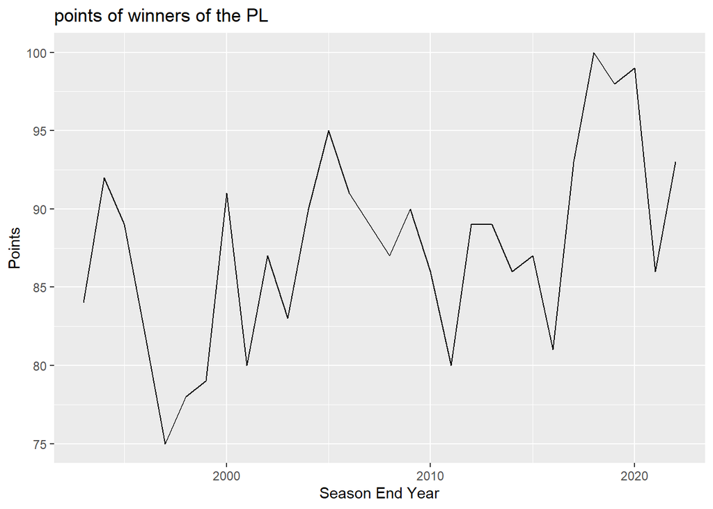

```r
ggplot(data=winner_points)+
  aes(x=Season_End_Year,y=winner_points)+
  geom_line()+
  ggtitle("points of winners of the PL")+
  xlab("Season End Year")+
  ylab("Points")
```

From this we see that in order for a Team to Win EPL it should accumulate at least 75 points.

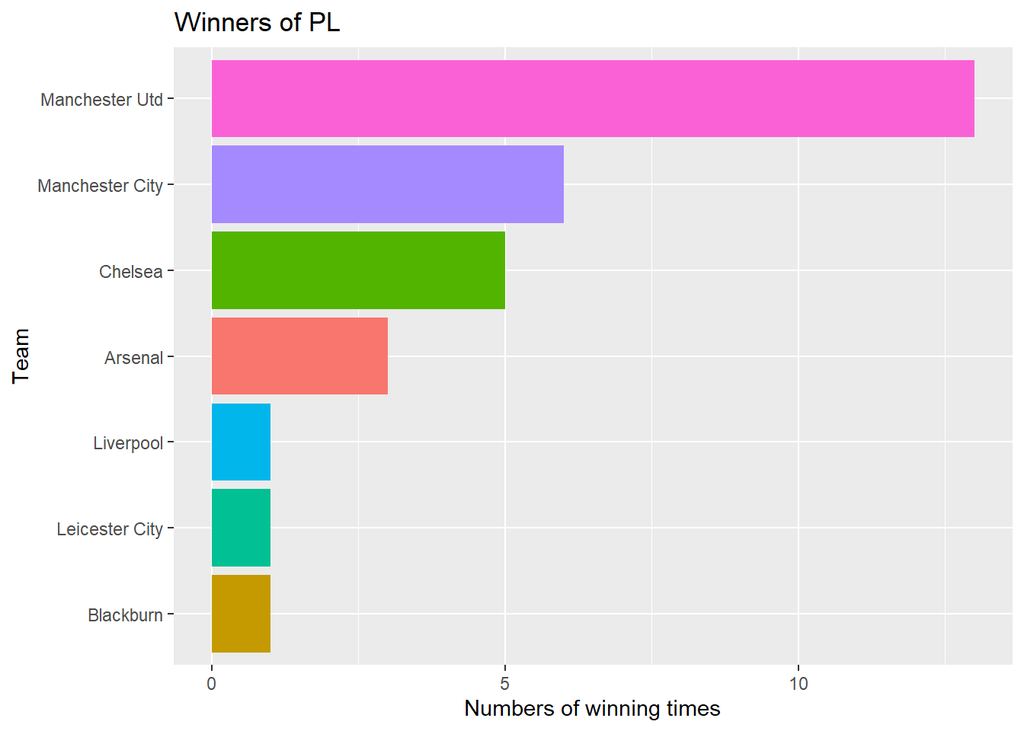

```r
winners_of_pl<-matrix(nrow = 30,ncol = 2)
winners_of_pl<-as.data.frame(winners_of_pl)
names(winners_of_pl)=c("Season_End_Year","winner")
for(i in 1993:2022)
{
  winners_of_pl[i-1992,1]<-paste0(i)
  winner_i<-PL_Table[[i]]$Team[PL_Table[[i]]$Rank==1]
  winners_of_pl[i-1992,2]<-winner_i
}

n_winners_of_pl<-winners_of_pl%>%
  group_by(winner)%>%
  count(winner)%>%
  arrange(desc(n))

## plotting the result
  ggplot(data = n_winners_of_pl,aes(x=n,y=reorder(winner,n),fill=winner))+
  geom_col()+
  ggtitle("Winners of PL")+
  ylab("Team")+
  xlab("Numbers of winning times")+
  theme(legend.position="none")
```

It’s clear that Manchester United has been the dominant force in the Premier League, having won numerous titles and trophies, with their last triumph being a decade ago. Upon investigation, it became apparent that a significant factor during their dominance was the coaching of Sir Alex Ferguson. This prompted us to explore the differences between Manchester United under Ferguson’s management and their performance post-Ferguson era. Additionally, we delved into analyzing coaches in the Premier League, focusing on those who have won the title twice or more, in an attempt to determine the best coach in the league’s history.

**We now move to our final analysis of Who is the best coach in premier league history.**

We will start analysis each manage with the club they managed , among the manager we will analyse the following *Sir Alex Ferguson*, *Pep Guardiola* ,*Jürgen Klopp* and *José Mourinho* .

- We will start with **Sir Alex ferguson** of Manchester united

  It’s evident that Manchester United has been the most successful club in terms of titles and trophies in the Premier League, with their last triumph occurring a decade ago. During our research, we noted that a key factor in Manchester United’s dominance was the coaching tenure of Sir Alex Ferguson. This prompted us to explore the disparities between Manchester United under Ferguson’s management and their performance post-Ferguson era. Furthermore, we sought to investigate the coaches in the Premier League, specifically focusing on those who have won the title twice or more, in order to determine who could be considered the best coach in the league’s history.

[figure not shown]

```r
## new subset with home results of Manchester United during the period of Sir Alex Ferguson
sir_home<-subset(PL_r,Home=="Manchester Utd"&Season_End_Year<=2013)%>%
  arrange(Season_End_Year,Wk)
head(sir_home)
```

```
##   Season_End_Year Wk       Date           Home HomeGoals AwayGoals
## 1            1993  2 1992-08-19 Manchester Utd         0         3
## 2            1993  3 1992-08-22 Manchester Utd         1         1
## 3            1993  6 1992-09-02 Manchester Utd         1         0
## 4            1993  7 1992-09-06 Manchester Utd         2         0
## 5            1993 10 1992-09-26 Manchester Utd         0         0
## 6            1993 12 1992-10-18 Manchester Utd         2         2
##             Away       FTR
## 1        Everton AWAY_WINS
## 2   Ipswich Town     DRAWS
## 3 Crystal Palace HOME_WINS
## 4   Leeds United HOME_WINS
## 5            QPR     DRAWS
## 6      Liverpool     DRAWS
```

```r
## new subset with away results of Manchester United during the period of Sir Alex Ferguson
sir_away<-subset(PL_r,Away=="Manchester Utd"&Season_End_Year<=2013)%>%
  arrange(Season_End_Year,Wk)
head(sir_away)
```

```
##   Season_End_Year Wk       Date            Home HomeGoals AwayGoals
## 1            1993  1 1992-08-15   Sheffield Utd         2         1
## 2            1993  4 1992-08-24     Southampton         0         1
## 3            1993  5 1992-08-29 Nott'ham Forest         0         2
## 4            1993  8 1992-09-12         Everton         0         2
## 5            1993  9 1992-09-19       Tottenham         1         1
## 6            1993 11 1992-10-03   Middlesbrough         1         1
##             Away       FTR
## 1 Manchester Utd HOME_WINS
## 2 Manchester Utd AWAY_WINS
## 3 Manchester Utd AWAY_WINS
## 4 Manchester Utd AWAY_WINS
## 5 Manchester Utd     DRAWS
## 6 Manchester Utd     DRAWS
```

```r
##sir points at home
sir_home_point<-sir_home%>%
  group_by(FTR)%>%
  count(FTR)
sir_home_point$points<-case_when(sir_home_point$FTR=="HOME_WINS"~sir_home_point$n*3,
                                 sir_home_point$FTR=="DRAWS"~sir_home_point$n*1,
                                 sir_home_point$FTR=="AWAY_WINS"~sir_home_point$n*0
                                 )
head(sir_home_point)
```

```
## # A tibble: 3 × 3
## # Groups:   FTR [3]
##   FTR           n points
##   <chr>     <int>  <dbl>
## 1 AWAY_WINS    34      0
## 2 DRAWS        66     66
## 3 HOME_WINS   305    915
```

```r
## sir points away home ground
sir_away_point<-sir_away%>%
  group_by(FTR)%>%
  count(FTR)
sir_away_point$points<-case_when(sir_away_point$FTR=="HOME_WINS"~sir_away_point$n*0,
                                 sir_away_point$FTR=="DRAWS"~sir_away_point$n*1,
                                 sir_away_point$FTR=="AWAY_WINS"~sir_away_point$n*3
                                 )
head(sir_away_point)
```

```
## # A tibble: 3 × 3
## # Groups:   FTR [3]
##   FTR           n points
##   <chr>     <int>  <dbl>
## 1 AWAY_WINS   223    669
## 2 DRAWS       102    102
## 3 HOME_WINS    80      0
```

```r
## sir goals

##home
sir_goals_home<-sir_home%>%
  group_by(Home)%>%
  summarize(all_home_goal=sum(sir_home$HomeGoals),all_home_goal_against=sum(sir_home$AwayGoals))
head(sir_goals_home)
```

```
## # A tibble: 1 × 3
##   Home           all_home_goal all_home_goal_against
##   <chr>                  <int>                 <int>
## 1 Manchester Utd           910                   270
```

```r
##away
sir_goals_away<-sir_away%>%
  group_by(Away)%>%
  summarize(all_away_goal=sum(sir_away$AwayGoals),all_away_goal_against=sum(sir_away$HomeGoals))
head(sir_goals_away)
```

```
## # A tibble: 1 × 3
##   Away           all_away_goal all_away_goal_against
##   <chr>                  <int>                 <int>
## 1 Manchester Utd           717                   433
```

Let now see the wins of sir alex at home

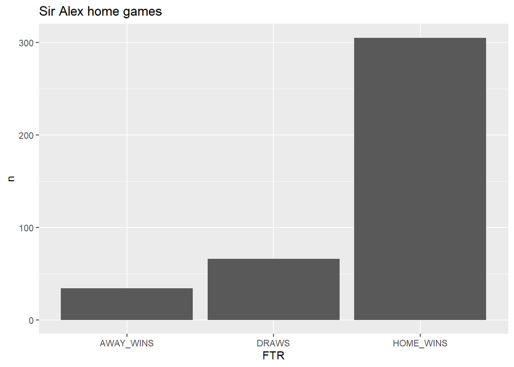

```r
sir_home_point %>% ggplot(mapping = aes(x=FTR,y=n))+geom_col()+ggtitle("Sir Alex home games")
```

Lets now calculate the probability of sir Alex wins ,loses and draws at home

```r
sir_home_point$Probabity<-sir_home_point$n/405
sir_home_point
```

```
## # A tibble: 3 × 4
## # Groups:   FTR [3]
##   FTR           n points Probabity
##   <chr>     <int>  <dbl>     <dbl>
## 1 AWAY_WINS    34      0    0.0840
## 2 DRAWS        66     66    0.163
## 3 HOME_WINS   305    915    0.753
```

We see that Sir Alex had $0.75$ of wining at home ,$0.16$ drawing and $0.083$ losing

Let’s now see how sir performed away games

[figure not shown]

```r
sir_away_point %>% ggplot(mapping = aes(x=FTR,y=n))+geom_col()+ggtitle("The number of games sir won at home")
```

Lets now calculate sir away wining probability

```r
sir_away_point$Probability <-sir_away_point$n/405
sir_away_point
```

```
## # A tibble: 3 × 4
## # Groups:   FTR [3]
##   FTR           n points Probability
##   <chr>     <int>  <dbl>       <dbl>
## 1 AWAY_WINS   223    669       0.551
## 2 DRAWS       102    102       0.252
## 3 HOME_WINS    80      0       0.198
```

We sir that sir Alex away wining probability was $0.55$ drawing $0.25$ Losing $0.197$

- We will now move to **Pep Guardiola** of Machester City

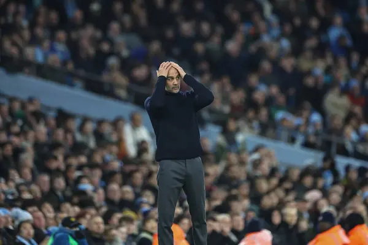

  Pep Guardiola commenced his tenure as Manchester City’s coach at the onset of the 2017 season and has continued in the role up to the present day.

  ```r
  ## new subset with home results of Manchester City during the period of Pep Guardiola
  pep_home<-subset(PL_r,Home=="Manchester City"&Season_End_Year>=2017)%>%
    arrange(Season_End_Year,Wk)
  head(pep_home)
  ```

  ```
  ##   Season_End_Year Wk       Date            Home HomeGoals AwayGoals
  ## 1            2017  1 2016-08-13 Manchester City         2         1
  ## 2            2017  3 2016-08-28 Manchester City         3         1
  ## 3            2017  5 2016-09-17 Manchester City         4         0
  ## 4            2017  8 2016-10-15 Manchester City         1         1
  ## 5            2017  9 2016-10-23 Manchester City         1         1
  ## 6            2017 11 2016-11-05 Manchester City         1         1
  ##            Away       FTR
  ## 1    Sunderland HOME_WINS
  ## 2      West Ham HOME_WINS
  ## 3   Bournemouth HOME_WINS
  ## 4       Everton     DRAWS
  ## 5   Southampton     DRAWS
  ## 6 Middlesbrough     DRAWS
  ```

  ```r
  ## new subset with away results of Manchester City during the period of Pep Guardiola
  pep_away<-subset(PL_r,Away=="Manchester City"&Season_End_Year>=2017)%>%
    arrange(Season_End_Year,Wk)
  head(pep_away)
  ```

  ```
  ##   Season_End_Year Wk       Date           Home HomeGoals AwayGoals
  ## 1            2017  2 2016-08-20     Stoke City         1         4
  ## 2            2017  4 2016-09-10 Manchester Utd         1         2
  ## 3            2017  6 2016-09-24   Swansea City         1         3
  ## 4            2017  7 2016-10-02      Tottenham         2         0
  ## 5            2017 10 2016-10-29      West Brom         0         4
  ## 6            2017 12 2016-11-19 Crystal Palace         1         2
  ##              Away       FTR
  ## 1 Manchester City AWAY_WINS
  ## 2 Manchester City AWAY_WINS
  ## 3 Manchester City AWAY_WINS
  ## 4 Manchester City HOME_WINS
  ## 5 Manchester City AWAY_WINS
  ## 6 Manchester City AWAY_WINS
  ```

  ```r
  ## Pep points at home ground
  pep_home_point<-pep_home%>%
    group_by(FTR)%>%
    count(FTR)
  pep_home_point$points<-case_when(pep_home_point$FTR=="HOME_WINS"~pep_home_point$n*3,
                                   pep_home_point$FTR=="DRAWS"~pep_home_point$n*1,
                                   pep_home_point$FTR=="AWAY_WINS"~pep_home_point$n*0
                                   )
  head(pep_home_point)
  ```

  ```
  ## # A tibble: 3 × 3
  ## # Groups:   FTR [3]
  ##   FTR           n points
  ##   <chr>     <int>  <dbl>
  ## 1 AWAY_WINS    12      0
  ## 2 DRAWS        20     20
  ## 3 HOME_WINS   114    342
  ```

  ```r
  ## Pep points at away grounds
  pep_away_point<-pep_away%>%
    group_by(FTR)%>%
    count(FTR)
  pep_away_point$points<-case_when(pep_away_point$FTR=="AWAY_WINS"~pep_away_point$n*3,
                                   pep_away_point$FTR=="HOME_WINS"~pep_away_point$n*0,
                                   pep_away_point$FTR=="DRAWS"~pep_away_point$n*1
                                   )
  head(pep_away_point)
  ```

  ```
  ## # A tibble: 3 × 3
  ## # Groups:   FTR [3]
  ##   FTR           n points
  ##   <chr>     <int>  <dbl>
  ## 1 AWAY_WINS   100    300
  ## 2 DRAWS        19     19
  ## 3 HOME_WINS    26      0
  ```

  ```
  ## # A tibble: 1 × 3
  ##   Home            all_home_goal all_home_goal_against
  ##   <chr>                   <int>                 <int>
  ## 1 Manchester City           404                   116
  ```

  ```r
  ##away
  pep_goals_away<-pep_away%>%
    group_by(Away)%>%
    summarize(all_away_goal=sum(pep_away$AwayGoals),all_away_goal_against=sum(pep_away$HomeGoals))
  head(pep_goals_home)
  ```

  ```
  ## # A tibble: 1 × 3
  ##   Home            all_home_goal all_home_goal_against
  ##   <chr>                   <int>                 <int>
  ## 1 Manchester City           404                   116
  ```

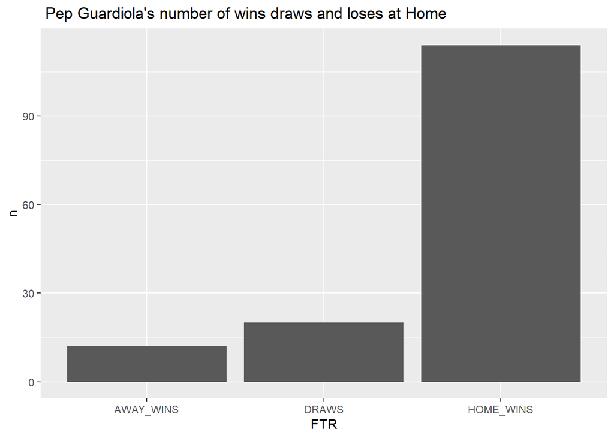

```r
ggplot(data=pep_home_point,mapping = aes(x=FTR,y=n))+geom_col()+labs(title = " Pep Guardiola's number of wins draws and loses at Home")
```

From this chart we see that pep has 12 Home loses , 20 draws and 114 Home wins . We can now calculate Pep Home winning , losing and drawing probability .

```r
pep_home_point$Probability <- pep_home_point$n/146
pep_home_point
```

```
## # A tibble: 3 × 4
## # Groups:   FTR [3]
##   FTR           n points Probability
##   <chr>     <int>  <dbl>       <dbl>
## 1 AWAY_WINS    12      0      0.0822
## 2 DRAWS        20     20      0.137
## 3 HOME_WINS   114    342      0.781
```

We see from the probability that pep has $0.08$ of losing a home game , $0.14$ drawing at home and $0.78$ probability of wining at home.

We move to pep probability of away games

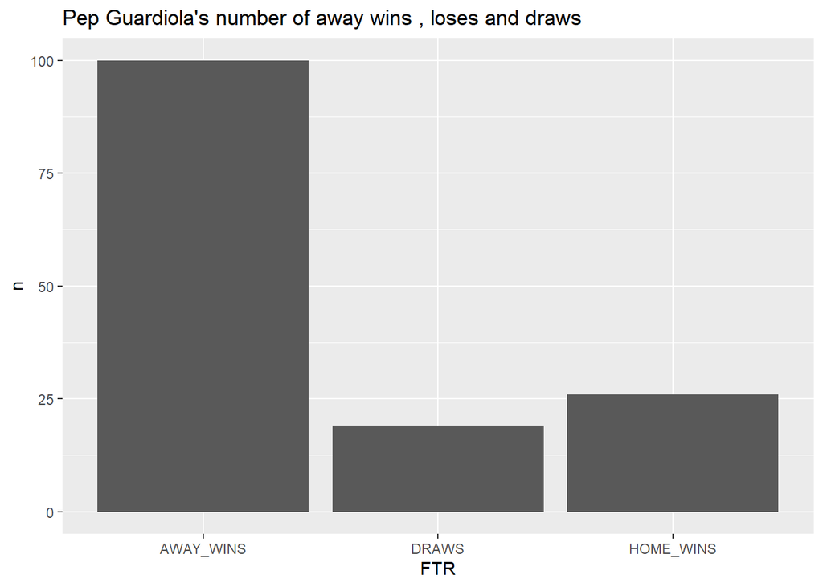

```r
pep_away_point %>% ggplot(mapping = aes(x=FTR,y=n))+geom_col()+labs(title = "Pep Guardiola's number of away wins , loses and draws")
```

```r
pep_away_point$probablity<- pep_away_point$n/145
pep_away_point
```

```
## # A tibble: 3 × 4
## # Groups:   FTR [3]
##   FTR           n points probablity
##   <chr>     <int>  <dbl>      <dbl>
## 1 AWAY_WINS   100    300      0.690
## 2 DRAWS        19     19      0.131
## 3 HOME_WINS    26      0      0.179
```

We see that Pep probability of wining away games is$0.689$, drawing $0.131$ and losing of $0.18$.

- We now move to Liverpool coach **Jürgen Klopp**

[figure not shown]

Klopp took over as manager of Liverpool in 2015 and has since led the team to significant success. Under his guidance, Liverpool reached the UEFA Champions League finals in 2018 and 2022, securing victory in 2019, their sixth title in the competition. In the 2018-19 Premier League season, Liverpool finished second with 97 points, the third-highest total in English top division history. Klopp’s team then won the UEFA Super Cup and FIFA Club World Cup in the following season. In 2019-20, Klopp led Liverpool to their first Premier League title, setting a club record of 99 points and breaking various top-flight records. His achievements earned him consecutive FIFA Coach of the Year awards in 2019 and 2020

```r
## new subset with home results of Liverpool during the period of Klopp
    klopp_home<-subset(PL_r,Home=="Liverpool"&Season_End_Year>=2015)%>%
      arrange(Season_End_Year,Wk)
    head(klopp_home)
```

```
##   Season_End_Year Wk       Date      Home HomeGoals AwayGoals        Away
## 1            2015  1 2014-08-17 Liverpool         2         1 Southampton
## 2            2015  4 2014-09-13 Liverpool         0         1 Aston Villa
## 3            2015  6 2014-09-27 Liverpool         1         1     Everton
## 4            2015  7 2014-10-04 Liverpool         2         1   West Brom
## 5            2015  9 2014-10-25 Liverpool         0         0   Hull City
## 6            2015 11 2014-11-08 Liverpool         1         2     Chelsea
##         FTR
## 1 HOME_WINS
## 2 AWAY_WINS
## 3     DRAWS
## 4 HOME_WINS
## 5     DRAWS
## 6 AWAY_WINS
```

```r
    ## new subset with away results of Manchester City during the period of klopp
    klopp_away<-subset(PL_r,Away=="Manchester City"&Season_End_Year>=2015)%>%
      arrange(Season_End_Year,Wk)
    head(klopp_away)
```

```
##   Season_End_Year Wk       Date          Home HomeGoals AwayGoals
## 1            2015  1 2014-08-17 Newcastle Utd         0         2
## 2            2015  4 2014-09-13       Arsenal         2         2
## 3            2015  6 2014-09-27     Hull City         2         4
## 4            2015  7 2014-10-04   Aston Villa         0         2
## 5            2015  9 2014-10-25      West Ham         2         1
## 6            2015 11 2014-11-08           QPR         2         2
##              Away       FTR
## 1 Manchester City AWAY_WINS
## 2 Manchester City     DRAWS
## 3 Manchester City AWAY_WINS
## 4 Manchester City AWAY_WINS
## 5 Manchester City HOME_WINS
## 6 Manchester City     DRAWS
```

```r
    ## Pep points at home ground
    klopp_home_point<-klopp_home%>%
      group_by(FTR)%>%
      count(FTR)
    klopp_home_point$points<-case_when(klopp_home_point$FTR=="HOME_WINS"~klopp_home_point$n*3,
                                     klopp_home_point$FTR=="DRAWS"~klopp_home_point$n*1,
                                     klopp_home_point$FTR=="AWAY_WINS"~klopp_home_point$n*0
                                     )
    head(klopp_home_point)
```

```
## # A tibble: 3 × 3
## # Groups:   FTR [3]
##   FTR           n points
##   <chr>     <int>  <dbl>
## 1 AWAY_WINS    16      0
## 2 DRAWS        42     42
## 3 HOME_WINS   125    375
```

```r
    ## Pep points at away grounds
    klopp_away_point<-klopp_away%>%
      group_by(FTR)%>%
      count(FTR)
    klopp_away_point$points<-case_when(klopp_away_point$FTR=="AWAY_WINS"~klopp_away_point$n*3,
                                     klopp_away_point$FTR=="HOME_WINS"~klopp_away_point$n*0,
                                     klopp_away_point$FTR=="DRAWS"~klopp_away_point$n*1
                                     )
    head(klopp_away_point)
```

```
## # A tibble: 3 × 3
## # Groups:   FTR [3]
##   FTR           n points
##   <chr>     <int>  <dbl>
## 1 AWAY_WINS   117    351
## 2 DRAWS        30     30
## 3 HOME_WINS    36      0
```

```r
    ## pep goals:

    ##home
    klopp_goals_home<-klopp_home%>%
      group_by(Home)%>%
      summarize(all_home_goal=sum(klopp_home$HomeGoals),all_home_goal_against=sum(klopp_home$AwayGoals))
     head(klopp_goals_home)
```

```
## # A tibble: 1 × 3
##   Home      all_home_goal all_home_goal_against
##   <chr>             <int>                 <int>
## 1 Liverpool           417                   152
```

```r
    ##away
    klopp_goals_away<-klopp_away%>%
      group_by(Away)%>%
      summarize(all_away_goal=sum(klopp_away$AwayGoals),all_away_goal_against=sum(klopp_away$HomeGoals))
    head(klopp_goals_home)
```

```
## # A tibble: 1 × 3
##   Home      all_home_goal all_home_goal_against
##   <chr>             <int>                 <int>
## 1 Liverpool           417                   152
```

We no use the visual to the number of wins draws and losses for Klopp

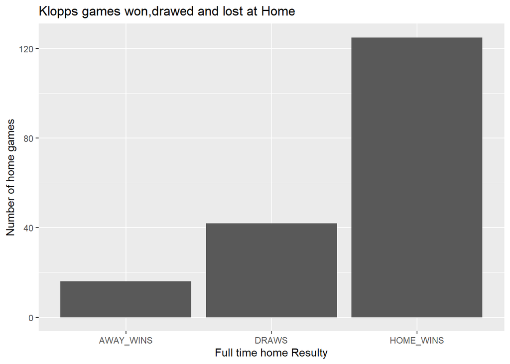

```r
klopp_home_point %>% ggplot(mapping=aes(x=FTR,y=n))+geom_col()+ggtitle("Klopps games won,drawed and lost at Home")+xlab("Full time home Resulty")+ylab("Number of home games")
```

Lets now calculate klopps probablity of wining home , Draw and losing at home

```r
klopp_home_point$Probability <- klopp_home_point$n/183
klopp_home_point
```

```
## # A tibble: 3 × 4
## # Groups:   FTR [3]
##   FTR           n points Probability
##   <chr>     <int>  <dbl>       <dbl>
## 1 AWAY_WINS    16      0      0.0874
## 2 DRAWS        42     42      0.230
## 3 HOME_WINS   125    375      0.683
```

**Let now move to away games for klopp**

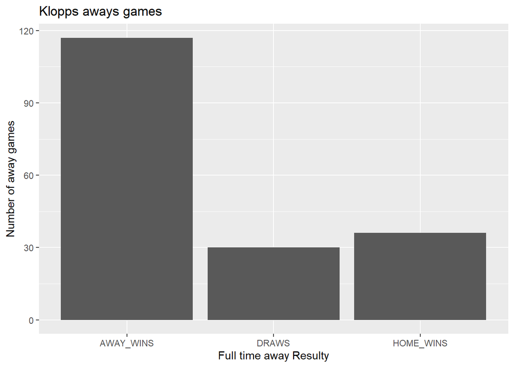

```r
klopp_away_point %>% ggplot(mapping = aes(x=FTR,y=n))+geom_col()+ggtitle("Klopps aways games")+xlab("Full time away Resulty")+ylab("Number of away games")
```

Lets now calculate the probability of klopp wining away games

```r
klopp_away_point$Probabilty<-klopp_away_point$n/183
klopp_away_point
```

```
## # A tibble: 3 × 4
## # Groups:   FTR [3]
##   FTR           n points Probabilty
##   <chr>     <int>  <dbl>      <dbl>
## 1 AWAY_WINS   117    351      0.639
## 2 DRAWS        30     30      0.164
## 3 HOME_WINS    36      0      0.197
```

- We now move to Chelsea manger José Mourinho.

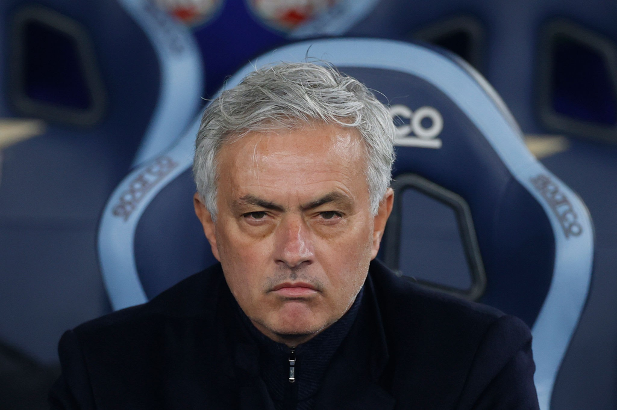

  Jose Mourinho became the manager of Chelsea twice, from 2004 to 2007 and then again from 2013 to 2015. His first unveiling at Stamford Bridge on June 2, 2004, marked the arrival of the most accomplished manager in Chelsea’s history. At just 41 years old, the Portuguese tactician had already secured major trophies including the European Cup, UEFA Cup, and domestic league title in his native Portugal, showcasing his remarkable success and pedigree in football management.

```r
## new subset with home results of Chelsea during the first period of Jose Mourinho
jose1_home<-subset(PL_r,Home=="Chelsea"& Date>="2004-08-14"&Date<="2007-09-15")%>%
  arrange(Season_End_Year,Wk)
  head(jose1_home)
```

```
##   Season_End_Year Wk       Date    Home HomeGoals AwayGoals           Away
## 1            2005  1 2004-08-15 Chelsea         1         0 Manchester Utd
## 2            2005  4 2004-08-28 Chelsea         2         1    Southampton
## 3            2005  6 2004-09-19 Chelsea         0         0      Tottenham
## 4            2005  8 2004-10-03 Chelsea         1         0      Liverpool
## 5            2005 10 2004-10-23 Chelsea         4         0      Blackburn
## 6            2005 12 2004-11-06 Chelsea         1         0        Everton
##         FTR
## 1 HOME_WINS
## 2 HOME_WINS
## 3     DRAWS
## 4 HOME_WINS
## 5 HOME_WINS
## 6 HOME_WINS
```

```r
## new subset with away results of Chelsea during the first period of Jose Mourinho
jose1_away<-subset(PL_r,Away=="Chelsea"& Date>="2004-08-14"&Date<="2007-09-15")%>%
  arrange(Season_End_Year,Wk)
head(jose1_away)
```

```
##   Season_End_Year Wk       Date            Home HomeGoals AwayGoals    Away
## 1            2005  2 2004-08-21 Birmingham City         0         1 Chelsea
## 2            2005  3 2004-08-24  Crystal Palace         0         2 Chelsea
## 3            2005  5 2004-09-11     Aston Villa         0         0 Chelsea
## 4            2005  7 2004-09-25   Middlesbrough         0         1 Chelsea
## 5            2005  9 2004-10-16 Manchester City         1         0 Chelsea
## 6            2005 11 2004-10-30       West Brom         1         4 Chelsea
##         FTR
## 1 AWAY_WINS
## 2 AWAY_WINS
## 3     DRAWS
## 4 AWAY_WINS
## 5 HOME_WINS
## 6 AWAY_WINS
```

```r
##jose points at home ground
jose1_home_point<-jose1_home%>%
  group_by(FTR)%>%
  count(FTR)
jose1_home_point$points<-case_when(jose1_home_point$FTR=="HOME_WINS"~jose1_home_point$n*3,
                                   jose1_home_point$FTR=="DRAWS"~jose1_home_point$n*1,
                                   jose1_home_point$FTR=="AWAY_WINS"~jose1_home_point$n*0
                                   )
head(jose1_home_point)
```

```
## # A tibble: 2 × 3
## # Groups:   FTR [2]
##   FTR           n points
##   <chr>     <int>  <dbl>
## 1 DRAWS        14     14
## 2 HOME_WINS    46    138
```

```r
##jose points at away grounds
jose1_away_point<-jose1_away%>%
  group_by(FTR)%>%
  count(FTR)
jose1_away_point$points<-case_when(jose1_away_point$FTR=="AWAY_WINS"~jose1_away_point$n*3,
                                   jose1_away_point$FTR=="HOME_WINS"~jose1_away_point$n*0,
                                   jose1_away_point$FTR=="DRAWS"~jose1_away_point$n*1
                                   )
jose1_away_point
```

```
## # A tibble: 3 × 3
## # Groups:   FTR [3]
##   FTR           n points
##   <chr>     <int>  <dbl>
## 1 AWAY_WINS    39    117
## 2 DRAWS        11     11
## 3 HOME_WINS    10      0
```

```r
## jose goals:

##home
jose1_goals_home<-jose1_home%>%
  group_by(Home)%>%
  summarize(all_home_goal=sum(jose1_home$HomeGoals),all_home_goal_against=sum(jose1_home$AwayGoals))
  head(jose1_goals_home)
```

```
## # A tibble: 1 × 3
##   Home    all_home_goal all_home_goal_against
##   <chr>           <int>                 <int>
## 1 Chelsea           123                    28
```

```r
##away
jose1_goals_away<-jose1_away%>%
  group_by(Away)%>%
  summarize(all_away_goal=sum(jose1_away$AwayGoals),all_away_goal_against=sum(jose1_away$HomeGoals))
head(jose1_goals_away)
```

```
## # A tibble: 1 × 3
##   Away    all_away_goal all_away_goal_against
##   <chr>           <int>                 <int>
## 1 Chelsea            92                    39
```

We now plot and see the number of wins on home games by Jose at home

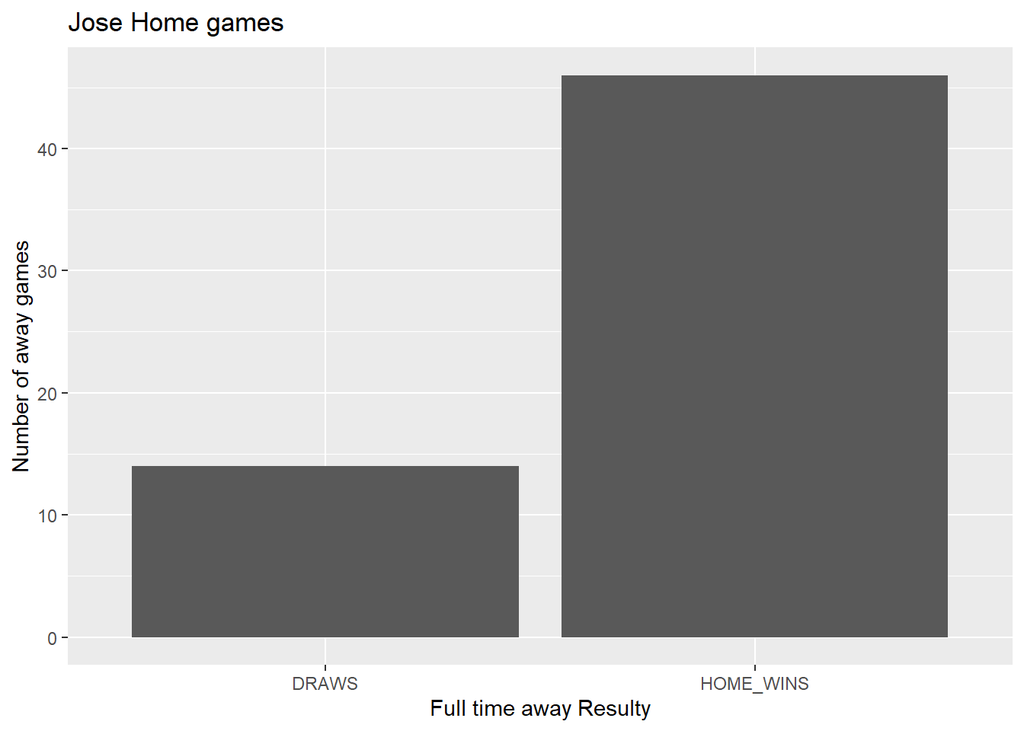

```r
jose1_home_point %>% ggplot(mapping = aes(x=FTR,y=n))+geom_col()+ggtitle("Jose Home games")+xlab("Full time away Resulty")+ylab("Number of away games")
```

Lets now calculate the probability of Jose wining home games

```r
jose1_home_point$Probabity<-jose1_home_point$n/60
jose1_home_point
```

```
## # A tibble: 2 × 4
## # Groups:   FTR [2]
##   FTR           n points Probabity
##   <chr>     <int>  <dbl>     <dbl>
## 1 DRAWS        14     14     0.233
## 2 HOME_WINS    46    138     0.767
```

We see from the probability that jose had $0.766$ wining home games and $0.233$ of drawing